# Analyzing data on the level of cognitive processes - ESCoP 2025

#### Plot model posteriors and model predicitions

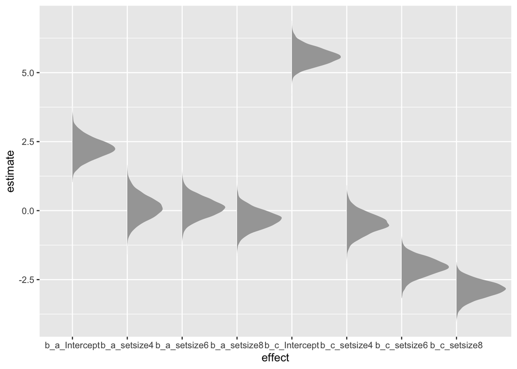

```r
# extract posterior samples
posterior <- as_draws_df(m3_fit_ss_exp1) %>%
  select(starts_with("b_")) %>%
  pivot_longer(cols = starts_with("b_"), names_to = "effect", values_to = "estimate") %>%
  filter(effect != "b_b_Intercept")

# plot posterior samples
ggplot(posterior, aes(x = effect, y = estimate)) +
  stat_slab()
```

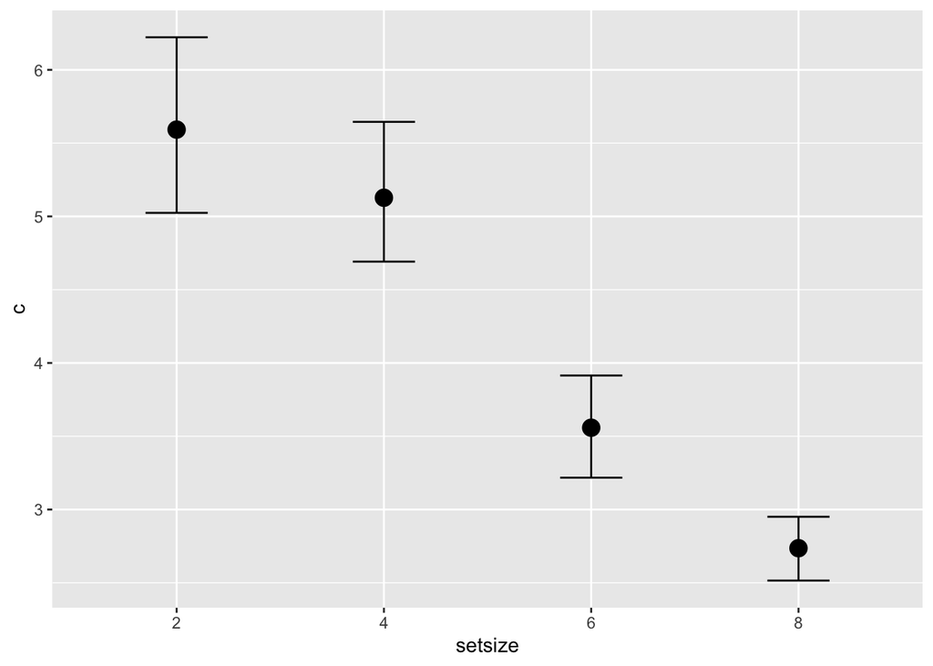

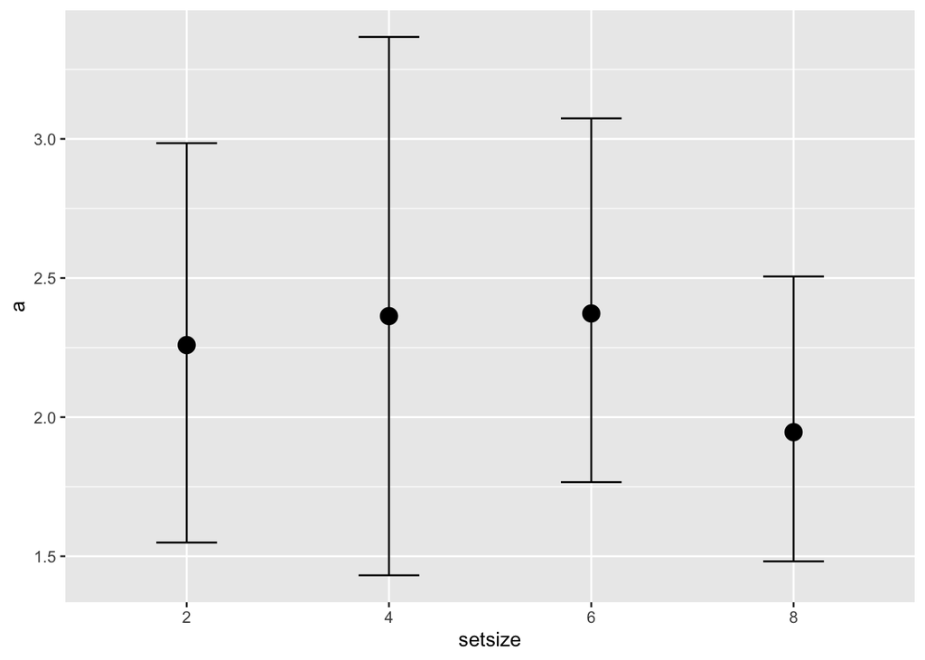

```r
# plot model predictions on native scale
conditional_effects(m3_fit_ss_exp1, categorical = T, effects = "setsize")
```

#### Hypothesis tests

```r
# to-be testes hypotheses
tests <- c(
  "c_Intercept = c_setsize4",
  "c_setsize4 = c_setsize6",
  "c_setsize6 = c_setsize8",
  "a_Intercept = a_setsize4",
  "a_setsize4 = a_setsize6",
  "a_setsize6 = a_setsize8"
)

hypothesis(m3_fit_ss_exp1, tests)
```

```
## Hypothesis Tests for class b:
##                 Hypothesis Estimate Est.Error CI.Lower CI.Upper Evid.Ratio
## 1 (c_Intercept)-(c_... = 0     6.06      0.63     4.86     7.35       0.00
## 2 (c_setsize4)-(c_s... = 0     1.57      0.25     1.11     2.09       0.00
## 3 (c_setsize6)-(c_s... = 0     0.82      0.12     0.59     1.07       0.00
## 4 (a_Intercept)-(a_... = 0     2.15      0.62     0.96     3.36       0.01
## 5 (a_setsize4)-(a_s... = 0    -0.01      0.51    -0.98     1.01       1.38
## 6 (a_setsize6)-(a_s... = 0     0.43      0.33    -0.21     1.08       0.95
##   Post.Prob Star
## 1      0.00    *
## 2      0.00    *
## 3      0.00    *
## 4      0.01    *
## 5      0.58
## 6      0.49
## ---
## 'CI': 90%-CI for one-sided and 95%-CI for two-sided hypotheses.
## '*': For one-sided hypotheses, the posterior probability exceeds 95%;
## for two-sided hypotheses, the value tested against lies outside the 95%-CI.
## Posterior probabilities of point hypotheses assume equal prior probabilities.
```

## Task 2: Experiment 2

In experiment 2, the same design as in experiment 1 was applied. However, the pool from which the list words were chosen from was restricted in comparison to experiment 1. We want to examine whether and how this switch from a large word pool in experiment 1 to a small word pool in experiment 2 changes the underlying cognitive processes of the set size effect.

1. Thus, we will first plot the data from experiment 2 descriptively (“exercise3_data_exp2.txt”).
2. Next, we implement the same basic M3 model and examine the model output. Plot the model results.
3. We test whether there are differences among the different set sizes using hypothesis tests. Do the results differ between experiment 1 and 2? If yes, how so?

### Load data

```r
# experiment 2
mydata_exp2 <- read.table(here('data', 'exercise3_data_exp2.txt'))
mydata_exp2$setsize <- as.factor(mydata_exp2$setsize)
```

### Descriptive proportions

```r
# calculate proportions
prop_data <- mydata_exp2 %>%
  group_by(id, setsize) %>%
  summarise(prop = sum(IIP) / sum(total), .groups = "drop") %>%
  group_by(setsize) %>%
  summarise(
    mean_prop = mean(prop),
    se = sd(prop) / sqrt(n()),
    lower = mean_prop - 1.96 * se,
    upper = mean_prop + 1.96 * se,
    .groups = "drop"
  )

prop_data
```

```
## # A tibble: 4 × 5
##   setsize mean_prop      se lower upper
##   <fct>       <dbl>   <dbl> <dbl> <dbl>
## 1 2           0.989 0.00480 0.980 0.999
## 2 4           0.97  0.00875 0.953 0.987
## 3 6           0.833 0.0244  0.785 0.881
## 4 8           0.693 0.0316  0.632 0.755
```

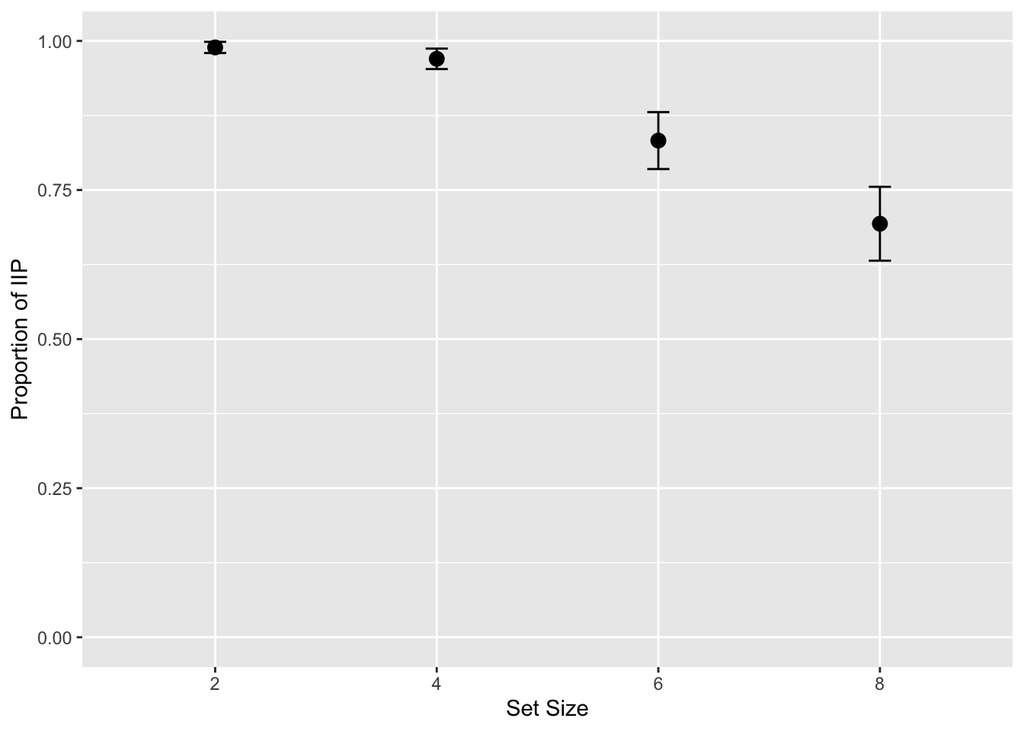

```r
# plot proportions
ggplot(prop_data, aes(x = factor(setsize), y = mean_prop)) +
  geom_point(size = 3) +
  geom_errorbar(aes(ymin = lower, ymax = upper), width = 0.1) +
  labs(y = "Proportion of IIP", x = "Set Size") +
  coord_cartesian(ylim = c(0, 1))
```